# EDA - Recenzje kawy

Jakub Wasiczek

2023-12-02

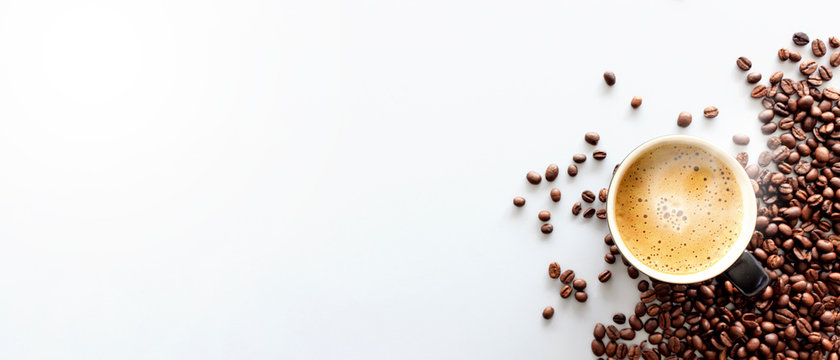

# Informacje o danych

Dane dotyczą różnych ciekawych informacji o kawie np. Odmian, sposobów obróbek, czy wysokości upraw.  
Pochodzą one z bazy danych **CQI** (Coffee Quality Institute), która zajmuje się utrzymywaniem i podwyższaniem międzynarodowych standardów kawy.  
Natomiast sam plik `.csv`, z którego korzystam podczas tej analizy został zaczerpnięty z *kaggle* i można go znaleźć pod [tym adresem](https://www.kaggle.com/datasets/fatihb/coffee-quality-data-cqi)

# Zmienne

**`country_of_origin`** - informuje nas o kraju, w którym była uprawiana kawa,  
**`farm_name`** - informuje nas o plantacji, z której pochodziła kawa,  
**`company`** - informuje nas o przedsiębiorstwie, które zajmuje się produkcją/importem/eksportem kawy,  
**`altitude`** - informuje nas o wysokości na jakiej była uprawiana kawa,  
**`region`** - informuje nas o regionie w jakim była uprawiana kawa,  
**`number_of_bags`** - informuje nas o ilości worków kawy dostarczonych przez przedsiębiorstwo,  
**`bag_weight`** - informuje nas o wadze kawy w worku [kg],  
**`harvest_year`** - informuje nas o okresie w jakim była zbierana kawa,  
**`variety`** - informuje nas o odmianie kawy,  
**`processing_method`** - informuje nas o metodzie obróbki owoców kawowca,  
**`moisture_percentage`** - informuje nas o poziomie wilgoci w ziarnach po obróbce, **`color`** - informuje nas o kolorze ziarna po obróbce,  
Poniższe zmienne dostarczają informacji na temat ocen (skala ciągła od 0 - 10), przyznanych przez recenzentów CQI w poszczególnych kategoriach. Dotyczą one już kawy po wypalniu, zmieleniu i zaparzeniu:  
**`aroma`** - zapach kawy po zmieleniu oraz zaparzeniu,  
**`flavor`** - smak kawy, wyczówalne w niej nuty smakowe np. toffi, orzechy laskowe, bergamotka,  
**`aftertaste`** - posmak, jaki zostaje po przełknięciu kawy,  
**`acidity`** - kwasowość, jest to o tyle ciekawa kategoria, gdyż w zależności od odmiany kawy, wysoki wynik będzie albo oznaczał kwaskowatość spotykaną w słodkich owocach (nie mylić z kwaśnością) lub w przypadku kaw z ameryki środkowej/południowej - jej brak.  
**`body`** - konsystencja kawy i jej fizyczne odczucie na języku,  
**`balance`** - jak dobrze się komponują napotykane nuty smakowe,  
**`uniformity`** - jak bardzo kawa trzyma poziom między kolejnymi partiamii zaparzania,  
**`overall`** - własne odczucia (poza kategoriami) recenzenta, w tym miejscu może np. zachwalić kawę dając jej wyższy wynik,  
**`total_cup_points`** - suma wszystkich punktów uzyskanych przez kawę (skala ciągła od 0 - 100).

[figure not shown]

# Przetwarzanie danych

```r
library(ggplot2)
library(dplyr)
library(tidyverse)
library(janitor)
library(stringr)
library(mice)
library(psych)
library(corrplot)
library(rcompanion)

coffee <- read.csv("C:/Users/qbawa/Desktop/Recenzje Kawy/df_arabica_clean.csv")

dim(coffee) #Dużo zmiennych - zobaczmy, które mogą się przydać
```

```
## [1] 207  41
```

```r
colnames(coffee)
```

```
##  [1] "X"                     "ID"                    "Country.of.Origin"
##  [4] "Farm.Name"             "Lot.Number"            "Mill"
##  [7] "ICO.Number"            "Company"               "Altitude"
## [10] "Region"                "Producer"              "Number.of.Bags"
## [13] "Bag.Weight"            "In.Country.Partner"    "Harvest.Year"
## [16] "Grading.Date"          "Owner"                 "Variety"
## [19] "Status"                "Processing.Method"     "Aroma"
## [22] "Flavor"                "Aftertaste"            "Acidity"
## [25] "Body"                  "Balance"               "Uniformity"
## [28] "Clean.Cup"             "Sweetness"             "Overall"
## [31] "Defects"               "Total.Cup.Points"      "Moisture.Percentage"
## [34] "Category.One.Defects"  "Quakers"               "Color"
## [37] "Category.Two.Defects"  "Expiration"            "Certification.Body"
## [40] "Certification.Address" "Certification.Contact"
```

Zmienne takie jak `X` oraz `ID` będą nieprzydatne w dalszej analizie.  
Nieistotne zdają się być również ceryfikaty oraz organizacje, które je nadają.  
Nie widzę również zastosowania dla numeru LOT oraz numeru ICO.

```r
length(unique(coffee$Quakers))
```

```
## [1] 11
```

Zgodnie z moimi podejrzeniami występuje dość mało obserwacji zmiennej `Quakers`.  
Wynika to z tego powodu, że są to po prostu ziarna, które zostały uzyskane z  
niedojrzałych owoców kawowca. W procesie zbierania owoców zawsze się trafi kilka z nich.  
Ich ilość nie wnosi nic do dalszej analizy.

```r
coffee2 <- coffee %>%
  select(-c("X", "ID", "Certification.Body", "Certification.Address",
            "Certification.Contact", "Lot.Number", "ICO.Number", "Quakers", "In.Country.Partner"))

head(coffee2,2)
```

```
##   Country.of.Origin                Farm.Name                     Mill
## 1          Colombia         Finca El Paraiso         Finca El Paraiso
## 2            Taiwan Royal Bean Geisha Estate Royal Bean Geisha Estate
##                    Company  Altitude         Region              Producer
## 1     Coffee Quality Union 1700-1930 Piendamo,Cauca Diego Samuel Bermudez
## 2 Taiwan Coffee Laboratory      1200         Chiayi                曾福森
##   Number.of.Bags Bag.Weight Harvest.Year         Grading.Date
## 1              1      35 kg  2021 / 2022 September 21st, 2022
## 2              1      80 kg  2021 / 2022  November 15th, 2022
##                                     Owner  Variety    Status
## 1                    Coffee Quality Union Castillo Completed
## 2 Taiwan Coffee Laboratory 台灣咖啡研究室    Gesha Completed
##         Processing.Method Aroma Flavor Aftertaste Acidity Body Balance
## 1 Double Anaerobic Washed  8.58    8.5       8.42    8.58 8.25    8.42
## 2            Washed / Wet  8.50    8.5       7.92    8.00 7.92    8.25
##   Uniformity Clean.Cup Sweetness Overall Defects Total.Cup.Points
## 1         10        10        10    8.58       0            89.33
## 2         10        10        10    8.50       0            87.58
##   Moisture.Percentage Category.One.Defects      Color Category.Two.Defects
## 1                11.8                    0      green                    3
## 2                10.5                    0 blue-green                    0
##             Expiration
## 1 September 21st, 2023
## 2  November 15th, 2023
```

Na pewno do usunięcia będą zmienne `Mill` i `Producer`. Gdyż w większości przypadków  
będą związane z samą farmą, a od tego mamy zmienną `Farm.Name`.  
Nie widzę też zastosowania dla `Grading.Date` oraz `expiration`

```r
coffee3 <- coffee2 %>%
  select(-c("Mill","Producer","Owner", "Grading.Date", "Expiration"))

summary(coffee3)
```

```
##  Country.of.Origin   Farm.Name           Company            Altitude
##  Length:207         Length:207         Length:207         Length:207
##  Class :character   Class :character   Class :character   Class :character
##  Mode  :character   Mode  :character   Mode  :character   Mode  :character
##
##
##
##     Region          Number.of.Bags    Bag.Weight        Harvest.Year
##  Length:207         Min.   :   1.0   Length:207         Length:207
##  Class :character   1st Qu.:   1.0   Class :character   Class :character
##  Mode  :character   Median :  14.0   Mode  :character   Mode  :character
##                     Mean   : 155.4
##                     3rd Qu.: 275.0
##                     Max.   :2240.0
##    Variety             Status          Processing.Method      Aroma
##  Length:207         Length:207         Length:207         Min.   :6.500
##  Class :character   Class :character   Class :character   1st Qu.:7.580
##  Mode  :character   Mode  :character   Mode  :character   Median :7.670
##                                                           Mean   :7.721
##                                                           3rd Qu.:7.920
##                                                           Max.   :8.580
##      Flavor        Aftertaste      Acidity           Body          Balance
##  Min.   :6.750   Min.   :6.67   Min.   :6.830   Min.   :6.830   Min.   :6.670
##  1st Qu.:7.580   1st Qu.:7.42   1st Qu.:7.500   1st Qu.:7.500   1st Qu.:7.500
##  Median :7.750   Median :7.58   Median :7.670   Median :7.670   Median :7.670
##  Mean   :7.745   Mean   :7.60   Mean   :7.690   Mean   :7.641   Mean   :7.644
##  3rd Qu.:7.920   3rd Qu.:7.75   3rd Qu.:7.875   3rd Qu.:7.750   3rd Qu.:7.790
##  Max.   :8.500   Max.   :8.42   Max.   :8.580   Max.   :8.250   Max.   :8.420
##    Uniformity      Clean.Cup    Sweetness     Overall         Defects
##  Min.   : 8.67   Min.   :10   Min.   :10   Min.   :6.670   Min.   :0
##  1st Qu.:10.00   1st Qu.:10   1st Qu.:10   1st Qu.:7.500   1st Qu.:0
##  Median :10.00   Median :10   Median :10   Median :7.670   Median :0
##  Mean   : 9.99   Mean   :10   Mean   :10   Mean   :7.677   Mean   :0
##  3rd Qu.:10.00   3rd Qu.:10   3rd Qu.:10   3rd Qu.:7.920   3rd Qu.:0
##  Max.   :10.00   Max.   :10   Max.   :10   Max.   :8.580   Max.   :0
##  Total.Cup.Points Moisture.Percentage Category.One.Defects    Color
##  Min.   :78.00    Min.   : 0.00       Min.   :0.0000       Length:207
##  1st Qu.:82.58    1st Qu.:10.10       1st Qu.:0.0000       Class :character
##  Median :83.75    Median :10.80       Median :0.0000       Mode  :character
##  Mean   :83.71    Mean   :10.74       Mean   :0.1353
##  3rd Qu.:84.83    3rd Qu.:11.50       3rd Qu.:0.0000
##  Max.   :89.33    Max.   :13.50       Max.   :5.0000
##  Category.Two.Defects
##  Min.   : 0.000
##  1st Qu.: 0.000
##  Median : 1.000
##  Mean   : 2.251
##  3rd Qu.: 3.000
##  Max.   :16.000
```

```r
coffee4 <- coffee3 %>%
  select(-c("Clean.Cup","Sweetness","Category.Two.Defects", "Category.One.Defects", "Defects"))

str(coffee4) #Ponownie sprawdzam dane w poszukiwaniu zbędnych zmiennych.
```

```
## 'data.frame':    207 obs. of  22 variables:
##  $ Country.of.Origin  : chr  "Colombia" "Taiwan" "Laos" "Costa Rica" ...
##  $ Farm.Name          : chr  "Finca El Paraiso" "Royal Bean Geisha Estate" "OKLAO coffee farms" "La Cumbre" ...
##  $ Company            : chr  "Coffee Quality Union" "Taiwan Coffee Laboratory" "Taiwan Coffee Laboratory" "Coffee Quality Union" ...
##  $ Altitude           : chr  "1700-1930" "1200" "1300" "1900" ...
##  $ Region             : chr  "Piendamo,Cauca" "Chiayi" "Laos Borofen Plateau" "Los Santos,Tarrazu" ...
##  $ Number.of.Bags     : int  1 1 19 1 2 5 1 1 1 320 ...
##  $ Bag.Weight         : chr  "35 kg" "80 kg" "25 kg" "22 kg" ...
##  $ Harvest.Year       : chr  "2021 / 2022" "2021 / 2022" "2021 / 2022" "2022" ...
##  $ Variety            : chr  "Castillo" "Gesha" "Java" "Gesha" ...
##  $ Status             : chr  "Completed" "Completed" "Completed" "Completed" ...
##  $ Processing.Method  : chr  "Double Anaerobic Washed" "Washed / Wet" "Semi Washed" "Washed / Wet" ...
##  $ Aroma              : num  8.58 8.5 8.33 8.08 8.33 8.33 8.33 8.25 8.08 8.08 ...
##  $ Flavor             : num  8.5 8.5 8.42 8.17 8.33 8.33 8.17 8.25 8.08 8.17 ...
##  $ Aftertaste         : num  8.42 7.92 8.08 8.17 8.08 8.25 8.08 8.17 8.25 8.08 ...
##  $ Acidity            : num  8.58 8 8.17 8.25 8.25 7.83 8 8 8.08 8.17 ...
##  $ Body               : num  8.25 7.92 7.92 8.17 7.92 7.83 7.83 7.92 7.92 8 ...
##  $ Balance            : num  8.42 8.25 8.17 8.08 7.92 8.17 8.25 8.08 8 8 ...
##  $ Uniformity         : num  10 10 10 10 10 10 10 10 10 10 ...
##  $ Overall            : num  8.58 8.5 8.33 8.25 8.25 8.25 8.25 8.08 8.25 8 ...
##  $ Total.Cup.Points   : num  89.3 87.6 87.4 87.2 87.1 ...
##  $ Moisture.Percentage: num  11.8 10.5 10.4 11.8 11.6 10.7 9.1 10 10.8 11 ...
##  $ Color              : chr  "green" "blue-green" "yellowish" "green" ...
```

```r
unique(coffee4$Status) #Wszystkie pozycje mają status "Completed"
```

```
## [1] "Completed"
```

```r
#dlatego nie mają sensu w dalszej analizie.
coffee4 <- subset(coffee4, select = -Status)

table(coffee4$Color) #Najwyraźniej jest to kolor kawy po obórbce.
```

```
##
##    blue-green  bluish-green browish-green      brownish         green
##            12            21             1             9           101
##      greenish   pale yellow   yello-green yellow- green  yellow-green
##            36             6             1             1            10
##  yellow green     yellowish
##             5             4
```

Ta zmienna może się przydać jako typ `factor`, jednakże przed tym warto byłoby połączyć kilka nazw.  
Zwłaszcza, że niektóre z nich są identyczne poza umiejscowieniem pauzy.

```r
yellow <- "yello"
blue <- "blu"
brown <- "brow"

coffee4 <- coffee4 %>%
  mutate(Color = ifelse(grepl(yellow, coffee4$Color), "yellow-green",
                       ifelse(grepl(blue, coffee4$Color), "blue-green",
                              ifelse(grepl(brown, coffee4$Color), "brown-green", "green"))))
coffee4$Color <- as.factor(coffee4$Color)
levels(coffee4$Color)
```

```
## [1] "blue-green"   "brown-green"  "green"        "yellow-green"
```

```r
table(coffee4$Processing.Method) #Może to być kolejna przydatna zmienna pod postacią factor.
```

```
##
##                                                          Anaerobico 1000h
##                                    5                                    1
##              Double Anaerobic Washed Double Carbonic Maceration / Natural
##                                    1                                    1
##                         Honey,Mossto                        Natural / Dry
##                                    1                                   46
##               Pulped natural / honey                          SEMI-LAVADO
##                                   25                                    1
##                          Semi Washed                         Washed / Wet
##                                    1                                  124
##                          Wet Hulling
##                                    1
```

Jednakże i w tym przypadku należałoby połączyc kilka zmiennych.  
Rodzaje obróki kawy postaram się przyporządkować na podstawie ich podobieństwa zarówno w celu jak i procesie.  
Pozycje o na prawdę odmiennych obróbkach usunę, gdyż występuje ich łącznie 3.

```r
coffee4 %>% #Występujące braki w nazwach również usunę,
  filter(Processing.Method == "") #gdyż występują między nimi spore różnice.
```

```
##   Country.of.Origin                    Farm.Name                  Company
## 1          Colombia                  El Diamante     Coffee Quality Union
## 2            Taiwan           愛姬咖啡莊園iGfarm Taiwan Coffee Laboratory
## 3         Indonesia PT Indo CafCo North Sumatera     InterAmerican Coffee
## 4          Colombia                              Coffee Quality Institute
## 5            Taiwan                 嵩岳咖啡莊園         宸嶧國際有限公司
##   Altitude                                                           Region
## 1     1350                                                          Quindio
## 2      150                                          壽豐鄉Shoufeng Township
## 3     1200                                                      Aceh Tengah
## 4
## 5     1200 Shibi, Gukeng Township, Yunlin County 郵遞區號 , Taiwan (R.O.C.)
##   Number.of.Bags Bag.Weight Harvest.Year               Variety
## 1              6       5 kg         2022 Castillo Paraguaycito
## 2              1      50 kg  2021 / 2022                Typica
## 3            320      60 kg         2022               Catimor
## 4              1       1 kg         2022
## 5            300       1 kg         2022                 Gesha
##   Processing.Method Aroma Flavor Aftertaste Acidity Body Balance Uniformity
## 1                    8.08   8.00       7.83    8.17 7.75    7.83         10
## 2                    7.92   8.00       7.92    8.00 7.58    7.75         10
## 3                    7.83   7.92       7.75    7.83 7.83    7.83         10
## 4                    7.83   7.75       7.50    7.58 7.67    7.67         10
## 5                    7.67   7.50       7.42    7.75 7.42    7.58         10
##   Overall Total.Cup.Points Moisture.Percentage        Color
## 1    8.00            85.67                11.3  brown-green
## 2    7.83            85.00                10.9        green
## 3    7.83            84.83                11.9   blue-green
## 4    7.67            83.67                12.4        green
## 5    7.58            82.92                10.2 yellow-green
```

```r
washed <- c("SEMI-LAVADO","Semi Washed", "Washed / Wet", "Wet Hulling")
honey <- c("Pulped natural / honey", "Honey,Mossto")
dry <- "Natural / Dry"

coffee4 <- coffee4 %>%
  mutate(Processing.Method = case_when(
    Processing.Method %in% washed ~ "Wet",
    Processing.Method %in% honey ~ "Honey",
    Processing.Method %in% dry ~ "Dry"
  )) %>%
  filter(Processing.Method %in% c("Wet","Honey","Dry"))

coffee4$Processing.Method <- as.factor(coffee4$Processing.Method)
levels(coffee4$Processing.Method)
```

```
## [1] "Dry"   "Honey" "Wet"
```

```r
tail(table(coffee4$Variety), 10) #Należy pozbyć się brakujących wartości oraz ustandaryzować zapis.
```

```
##
##                     Sl34+Gesha                         Typica
##                              1                             22
##                  Typica + SL34 Typica Bourbon Caturra Catimor
##                              1                              1
##                   Typica Gesha                         unknow
##                              1                              1
##                        unknown          Wolishalo,Kurume,Dega
##                             12                              1
##                 Yellow Bourbon                  Yellow Catuai
##                              2                              1
```

```r
coffee4 <- coffee4 %>%
  mutate(Variety = ifelse(Variety == "unknow", "unknown", Variety)) %>%
  filter(Variety != "")

coffee4$Variety<-str_to_title(coffee4$Variety)
coffee4$Variety <- str_replace_all(coffee4$Variety, "[^a-zA-Z0-9]", " ")
coffee4$Variety <- str_squish(coffee4$Variety)

tail(table(coffee4$Variety), 10)
```

```
##
##                           Sl34                     Sl34 Gesha
##                              8                              1
##                         Typica Typica Bourbon Caturra Catimor
##                             22                              1
##                   Typica Gesha                    Typica Sl34
##                              1                              1
##                        Unknown          Wolishalo Kurume Dega
##                             13                              1
##                 Yellow Bourbon                  Yellow Catuai
##                              2                              1
```

Tak samo podejdę do zmiennej `Region`.

```r
tail(table(coffee4$Region), 10)
```

```
##
##      卓溪鄉Zhuoxi Township                   台灣屏東
##                          1                          2
##    壽豐鄉Shoufeng Township                     新北市
##                          2                          2
##                     新竹縣                     桃園市
##                         11                          4
##        玉里鎮Yuli Township 秀林鄉Show Linxia Township
##                          1                          1
##                     臺北市                     苗栗縣
##                          1                          7
```

```r
coffee4$Region <- str_to_title(coffee4$Region)

coffee4 <- coffee4 %>% #Najpierw zajmę się chińskimi znakami
  mutate(Region =
           ifelse(grepl("苗栗縣", Region),"Miaoli Township",
         ifelse(grepl("臺北市", Region),"Taipei",
         ifelse(grepl("秀林鄉", Region),"Linxia Township",
         ifelse(grepl("玉里鎮", Region),"Yuli Township",
         ifelse(grepl("桃園市", Region),"Taoyuan",
         ifelse(grepl("新竹縣", Region),"Hsinchu County",
         ifelse(grepl("新北市", Region),"New Taipei City",
         ifelse(grepl("壽豐鄉", Region),"Shoufeng Township",
         ifelse(grepl("台灣屏東", Region),"Pingtung, Taiwan",
         ifelse(grepl("卓溪鄉", Region),"Zhuoxi Township", Region)))))))))))

coffee4 <- coffee4 %>%
  mutate(Region = ifelse(grepl("郵遞區號", Region),
                  "Gukeng Township Yunlin County", Region))

coffee4$Region <- str_replace_all(coffee4$Region, ",", " ")
coffee4$Region <- str_replace_all(coffee4$Region, " - ", " ")
coffee4$Region <- str_squish(coffee4$Region)

tail(table(coffee4$Region), 10)
```

```
##
##                                       Tolima
##                                            2
##                                     Veracruz
##                                            1
##                                   Villa Rica
##                                            1
## Volcan Chinchontepek San Vicente El Salvador
##                                            2
##     Volcan De San Vicente La Paz El Salvador
##                                            1
##                                 West Villege
##                                            1
##                                Yuli Township
##                                            1
##                                       Yunlin
##                                            7
##                              Zhuoxi Township
##                                            1
##                           Zongolica Veracruz
##                                            1
```

Warto jeszcze przyjrzeć się zmiennym `Harvest.Year` oraz `Altitude`.

```r
table(coffee4$Harvest.Year)
```

```
##
## 2017 / 2018 2018 / 2019        2021 2021 / 2022        2022 2022 / 2023
##           1           1          13          96          40          40
##        2023
##           3
```

Uważam, że może byc przydatna jako `factor`.  
Przed tym jednak pozbęde się zmiennych, których występowanie jest marginalne.

```r
coffee4 <- coffee4 %>%
  filter(!Harvest.Year %in% c("2017 / 2018","2018 / 2019", "2023"))

coffee4$Harvest.Year <- as.factor(coffee4$Harvest.Year)
```

Teraz przejdę do zmiennej `Altitude`.  
Uważam, że mogłaby być o wiele przydatniejsza jako typ `num`.  
Przypadki tej zmiennej, które występują w przedziałach uśrednię.

```r
head(table(coffee4$Altitude), 10)
```

```
##
##        1000        1040        1060        1100   1100-1200        1200
##           3           1           1           5           1          19
##   1200-1350 1200 - 1300 1200 - 1580   1200~1600
##           1           1           2           1
```

```r
alt <- substring(coffee4$Altitude, 1)
alt <- str_replace_all(coffee4$Altitude, "[^a-zA-Z0-9]", " ")
alt <- chartr("A", " ", alt)
alt <- str_squish(alt)
listAlt <- strsplit(alt, c(" "))
num_list <- lapply(listAlt, as.numeric)
num_list <- lapply(num_list,mean)
mean_alt <- unlist(num_list)

coffee4 <- coffee4 %>%
  mutate(Altitude = mean_alt)
```

Ostatnią zmienną, którą poddamy zmianą będzie `Bag.Weight`, chcemy żeby była typu `int`.

```r
head(table(coffee4$Bag.Weight), 10)
```

```
##
##     1 kg    10 kg   100 kg   104 kg   110 kg    12 kg    13 kg    15 kg
##       11        5        6        1        1        2        2       10
##    16 kg 19200 kg
##        2        2
```

```r
#Usuwam wszystkie litery, a pozostałe po nich spacje usuwam za pomocą trimws().
coffee4$Bag.Weight <- trimws(str_replace_all(coffee4$Bag.Weight, "[:alpha:]", ""))
coffee4$Bag.Weight <- as.numeric(coffee4$Bag.Weight)

head(table(coffee4$Bag.Weight), 10)
```

```
##
##  1  2  3  4  5  6  8 10 12 13
## 11  5  1  2  9  1  2  5  2  2
```

Sprawdźmy teraz czy nadal w danych występują jakieś braki.

```
##  /\     /\
## {  `---'  }
## {  O   O  }
## ==>  V <==  No need for mice. This data set is completely observed.
##  \  \|/  /
##   `-----'
```

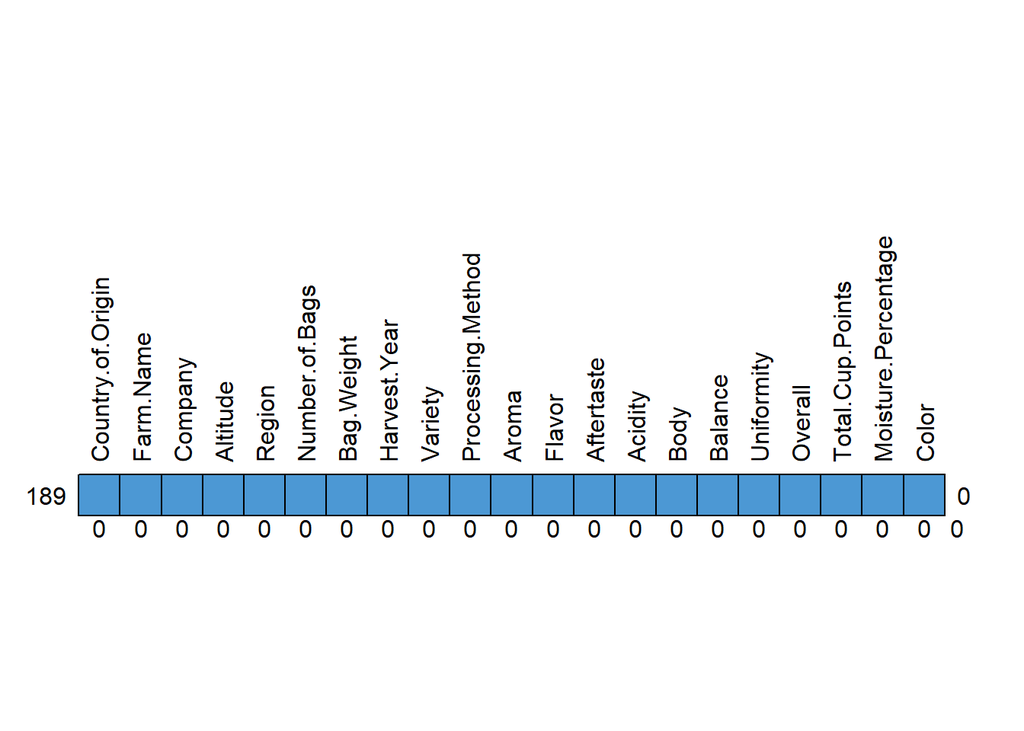

```
##     Country.of.Origin Farm.Name Company Altitude Region Number.of.Bags
## 189                 1         1       1        1      1              1
##                     0         0       0        0      0              0
##     Bag.Weight Harvest.Year Variety Processing.Method Aroma Flavor Aftertaste
## 189          1            1       1                 1     1      1          1
##              0            0       0                 0     0      0          0
##     Acidity Body Balance Uniformity Overall Total.Cup.Points
## 189       1    1       1          1       1                1
##           0    0       0          0       0                0
##     Moisture.Percentage Color
## 189                   1     1 0
##                       0     0 0
```

```r
md.pattern(coffee4, rotate.names = T)
```

Jak widać udało się pozbyć wszystkich braków.

Na samym końcu przerzucę wyczyszczone dane do nowej ramki danych,  
posłużę się `clean_names()` z pakietu `janitor` aby mieć bardziej standardowe nazwy kolumn.

```r
clean_coffee <- coffee4 %>%
  janitor::clean_names()
```

Teraz mogę przejrzeć wyczyszczone dane i zacząć je analizować.

# Analiza danych

```r
summary(clean_coffee)
```

```
##  country_of_origin   farm_name           company             altitude
##  Length:189         Length:189         Length:189         Min.   : 139
##  Class :character   Class :character   Class :character   1st Qu.:1000
##  Mode  :character   Mode  :character   Mode  :character   Median :1340
##                                                           Mean   :1318
##                                                           3rd Qu.:1600
##                                                           Max.   :5400
##     region          number_of_bags     bag_weight           harvest_year
##  Length:189         Min.   :   1.0   Min.   :    1.0   2021       :13
##  Class :character   1st Qu.:   1.0   1st Qu.:   15.0   2021 / 2022:96
##  Mode  :character   Median :  14.0   Median :   30.0   2022       :40
##                     Mean   : 156.5   Mean   :  246.5   2022 / 2023:40
##                     3rd Qu.: 275.0   3rd Qu.:   69.0
##                     Max.   :2240.0   Max.   :19200.0
##    variety          processing_method     aroma           flavor
##  Length:189         Dry  : 42         Min.   :7.170   Min.   :7.080
##  Class :character   Honey: 24         1st Qu.:7.580   1st Qu.:7.580
##  Mode  :character   Wet  :123         Median :7.670   Median :7.750
##                                       Mean   :7.728   Mean   :7.753
##                                       3rd Qu.:7.920   3rd Qu.:7.920
##                                       Max.   :8.500   Max.   :8.500
##    aftertaste       acidity           body          balance
##  Min.   :6.670   Min.   :6.830   Min.   :6.830   Min.   :6.670
##  1st Qu.:7.420   1st Qu.:7.500   1st Qu.:7.500   1st Qu.:7.500
##  Median :7.580   Median :7.670   Median :7.670   Median :7.670
##  Mean   :7.604   Mean   :7.688   Mean   :7.646   Mean   :7.651
##  3rd Qu.:7.750   3rd Qu.:7.830   3rd Qu.:7.750   3rd Qu.:7.750
##  Max.   :8.250   Max.   :8.330   Max.   :8.250   Max.   :8.250
##    uniformity        overall      total_cup_points moisture_percentage
##  Min.   : 8.670   Min.   :6.670   Min.   :78.00    Min.   : 0.00
##  1st Qu.:10.000   1st Qu.:7.500   1st Qu.:82.67    1st Qu.:10.00
##  Median :10.000   Median :7.750   Median :83.83    Median :10.80
##  Mean   : 9.989   Mean   :7.682   Mean   :83.74    Mean   :10.69
##  3rd Qu.:10.000   3rd Qu.:7.920   3rd Qu.:84.83    3rd Qu.:11.50
##  Max.   :10.000   Max.   :8.580   Max.   :87.58    Max.   :13.50
##           color
##  blue-green  : 26
##  brown-green :  8
##  green       :129
##  yellow-green: 26
##
##
```

```r
clean_coffee %>%
  select("altitude", "number_of_bags", "bag_weight", "aroma", "flavor" ,
         "aftertaste", "acidity", "body", "balance" ,"uniformity", "overall",
         "total_cup_points", "moisture_percentage") %>%
  describe() #Staram się uzyskać statystyki opisowe moich zmiennych liczbowych.
```

```
##                     vars   n    mean      sd  median trimmed    mad    min
## altitude               1 189 1318.00  746.31 1340.00 1282.40 385.48 139.00
## number_of_bags         2 189  156.53  249.77   14.00  109.38  19.27   1.00
## bag_weight             3 189  246.53 1965.75   30.00   39.92  38.55   1.00
## aroma                  4 189    7.73    0.27    7.67    7.73   0.25   7.17
## flavor                 5 189    7.75    0.27    7.75    7.76   0.25   7.08
## aftertaste             6 189    7.60    0.27    7.58    7.61   0.24   6.67
## acidity                7 189    7.69    0.25    7.67    7.69   0.25   6.83
## body                   8 189    7.65    0.23    7.67    7.65   0.24   6.83
## balance                9 189    7.65    0.24    7.67    7.65   0.25   6.67
## uniformity            10 189    9.99    0.11   10.00   10.00   0.00   8.67
## overall               11 189    7.68    0.29    7.75    7.68   0.25   6.67
## total_cup_points      12 189   83.74    1.64   83.83   83.76   1.62  78.00
## moisture_percentage   13 189   10.69    1.28   10.80   10.75   1.19   0.00
##                          max    range   skew kurtosis     se
## altitude             5400.00  5261.00   2.42    11.56  54.29
## number_of_bags       2240.00  2239.00   3.66    24.17  18.17
## bag_weight          19200.00 19199.00   9.48    88.46 142.99
## aroma                   8.50     1.33   0.17    -0.38   0.02
## flavor                  8.50     1.42  -0.12    -0.04   0.02
## aftertaste              8.25     1.58  -0.21     0.62   0.02
## acidity                 8.33     1.50  -0.30     0.33   0.02
## body                    8.25     1.42  -0.33     0.66   0.02
## balance                 8.25     1.58  -0.24     0.85   0.02
## uniformity             10.00     1.33 -10.82   121.78   0.01
## overall                 8.58     1.91  -0.08     0.38   0.02
## total_cup_points       87.58     9.58  -0.24     0.27   0.12
## moisture_percentage    13.50    13.50  -3.04    23.98   0.09
```

Zacznę od analizy zmiennej `total_cup_points`, jak widać dzięki funkcji `describe()`  
będzie ona miała najprawdopodobniej rozkład zbliżony do normalnego.

## **Pytanie 1:** *Z jakiego kraju przeciętnie pochodzą najlepsze kawy?*

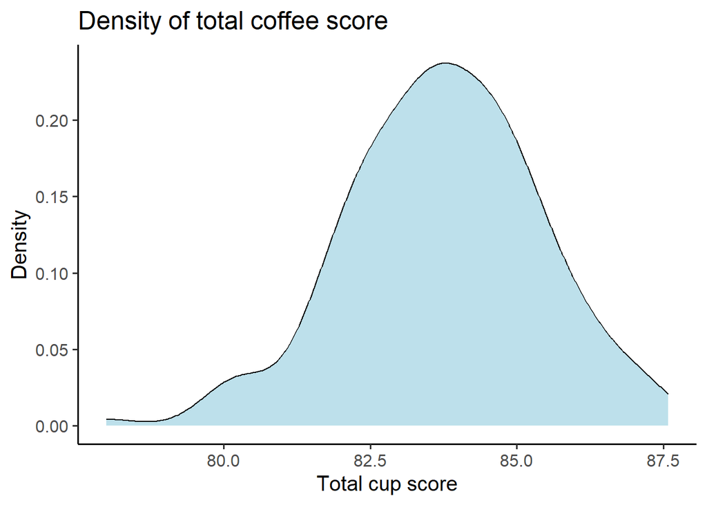

```r
clean_coffee %>%
  ggplot() +
  geom_density(mapping = aes(x = total_cup_points),
               fill = "lightblue",
               alpha = 0.8) +
  ggtitle("Density of total coffee score") +
  xlab("Total cup score") +
  ylab("Density") +
  theme_classic(base_size = 15,
                base_rect_size = 0.5)
```

Większość obserwacji jest skoncentrowana wokół wyników z przedziału 82,5 - 85.

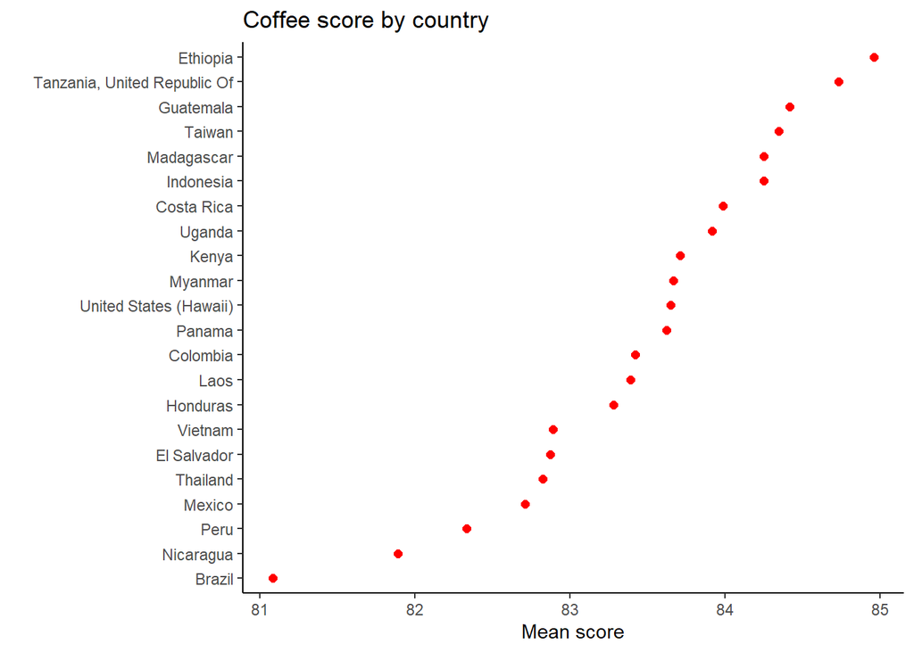

```r
clean_coffee %>%
  select(country_of_origin, total_cup_points) %>%
  group_by(country_of_origin) %>%
  summarize(mean_score = mean(total_cup_points)) %>%
  ggplot(aes(x = mean_score, y = reorder(country_of_origin, mean_score))) +
  geom_point(size = 2, color = "red") +
  theme_classic() +
  ggtitle("Coffee score by country") +
  xlab("Mean score") +
  ylab("")
```

Stąd widać, że przeciętnie najlepiej sa oceniane kawy z Etiopii i Tanzanii.  
Najgorzej wypadają kawy z Brazylii.

Ostatecznie wypada jeszcze sprawdzić skąd pochodzą najwyżej oceniane kawy.

```r
clean_coffee %>%
  select(country_of_origin, total_cup_points) %>%
  top_n(5, total_cup_points)
```

```
##   country_of_origin total_cup_points
## 1            Taiwan            87.58
## 2              Laos            87.42
## 3        Costa Rica            87.17
## 4          Colombia            87.08
## 5         Guatemala            87.00
```

Co ciekawe najwyżej oceniane kawy nie pochodziły ani z Etopii ani z Tanzanii.

## **Pytanie 2:** *Jak wilgoć kawy wpływa na jej wynik w degustacji?*

Mimo że ziarna kawy zielonej, gotowe do palenia mogą wydawać się suche,  
wciąż zawierają wilgoć.  
Typowe dojrzałe, nieprzetworzone ziarno kawy,  
powinno zawierać około 45–55% wilgoci po zebraniu.  
Procesowanie i suszenie obniżą jego zawartość wilgoci do 10–12%.  
Odpowiednie poziomy wilgoci pozwalają uzyskać wysokie oceny w degustacji,  
zrównoważoną kwasowość i odpowiedni aromat.  
Ogólnie przyjmuje się, że poziom wilgoci powinien przyjmować 10–12%.

```r
table(clean_coffee$moisture_percentage)
```

```
##
##    0  8.1  8.2  8.4  8.5  8.9    9  9.1  9.2  9.3  9.4  9.5  9.6  9.7  9.8  9.9
##    1    1    1    3    1    1    1    3    3    1    2    4    5    5    5    3
##   10 10.1 10.2 10.3 10.4 10.5 10.6 10.7 10.8 10.9   11 11.1 11.2 11.3 11.4 11.5
##   11    6    5    5    7    6   10    4    5    4    8    3    8   11    5    5
## 11.6 11.7 11.8 11.9   12 12.1 12.2 12.3   13 13.1 13.3 13.5
##   13    5   12    3    2    2    1    2    1    2    2    1
```

Jak widać trafił nam się jeden przypadek, gdzie wartość wilgoci wynosi 0%.  
Zdaje się, że jest to błąd - ten przypadek nie będzie brany pod uwagę.

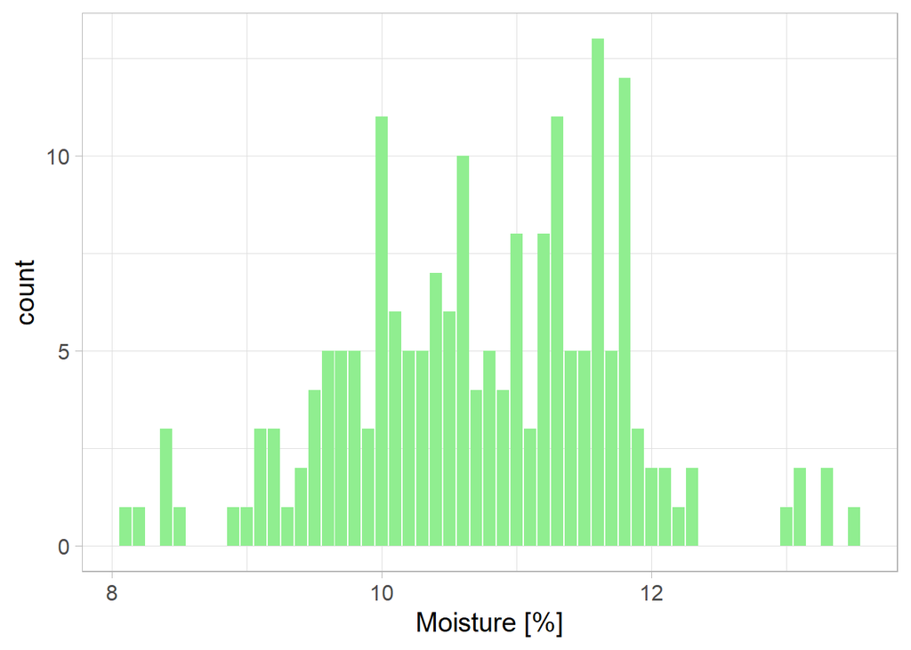

```r
clean_coffee %>%
  select(moisture_percentage) %>%
  filter(moisture_percentage > 0) %>%
  ggplot() +
  geom_bar(mapping = aes(x = moisture_percentage), fill = "lightgreen") +
  xlab("Moisture [%]") +
  theme_light(base_size = 15,
              base_rect_size = 0.5)
```

Rozkład zmiennej `moisture_percentage` nie jest rozkładem normalnym.  
Jak widać mamy dość spory przedział wartości, warto to przedstawić na boxplocie.

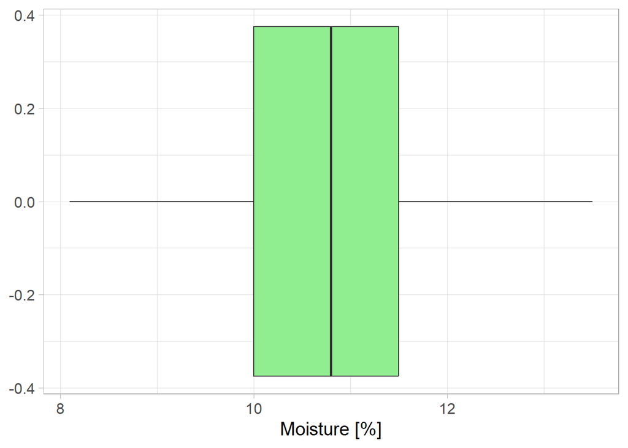

```r
clean_coffee %>%
  filter(moisture_percentage > 0) %>%
  ggplot() +
  geom_boxplot(mapping = aes(x = moisture_percentage), fill = "lightgreen") +
  theme_light(base_size = 15,
              base_rect_size = 0.5) +
  xlab("Moisture [%]")
```

Około połowa obserwacji przyjmuje wartości z przedziału 10 - 11,5%,  
co wpasowywuje się w przyjęty standard 10-12%.

Zatem jak poziom wilgoci,  
będzie oddziałoywał na uzyskane wyniki w aromacie i kwaskowatości?  
Wedle założeń, odchylenia od tej normy mają przyczynić do gorszych wyników.

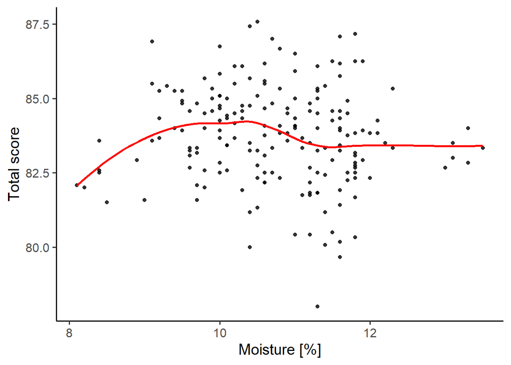

```r
clean_coffee %>%
  filter(moisture_percentage > 0) %>%
  ggplot() +
  geom_point(mapping = aes(x = moisture_percentage, y = total_cup_points),alpha = 0.8) +
  geom_smooth(mapping = aes(x = moisture_percentage, y = total_cup_points),color = "red", se = FALSE) +
  xlab("Moisture [%]")+
  ylab("Total score") +
  theme_classic(base_size = 15,
                base_rect_size = 0.5)
```

Jak widać raczej nie ma powiązania między %wilgoci a uzyskiwanym wynikem.  
Można to jeszcze pokazać licząc korelacje.

```r
clean_coffee %>%
  filter(moisture_percentage > 0) %>%
  summarise(cor(moisture_percentage, total_cup_points,  method = "spearman"))
```

```
##   cor(moisture_percentage, total_cup_points, method = "spearman")
## 1                                                      -0.1222144
```

Jak widać nie istnieje zależność między zmiennymi.  
Co z poszczególnymi aspektami kawy - kwaskowatością i aromatem?

```r
clean_coffee %>%
  filter(moisture_percentage > 0) %>%
  summarise(cor(moisture_percentage, aroma,  method = "spearman"))
```

```
##   cor(moisture_percentage, aroma, method = "spearman")
## 1                                          -0.06199578
```

```r
clean_coffee %>%
  filter(moisture_percentage > 0) %>%
  summarise(cor(moisture_percentage, acidity,  method = "spearman"))
```

```
##   cor(moisture_percentage, acidity, method = "spearman")
## 1                                            -0.08098338
```

Jak widać zmienne są nieskorelowane.

## **Pytanie 3:** *Jaka metoda obróbki kawy pozwala na największą produkcję kawy?*

Najskuteczniejsze metody powinny być z kategorii obórbek mokrych,  
ponieważ ten proces zajmuje najmniej czasu.

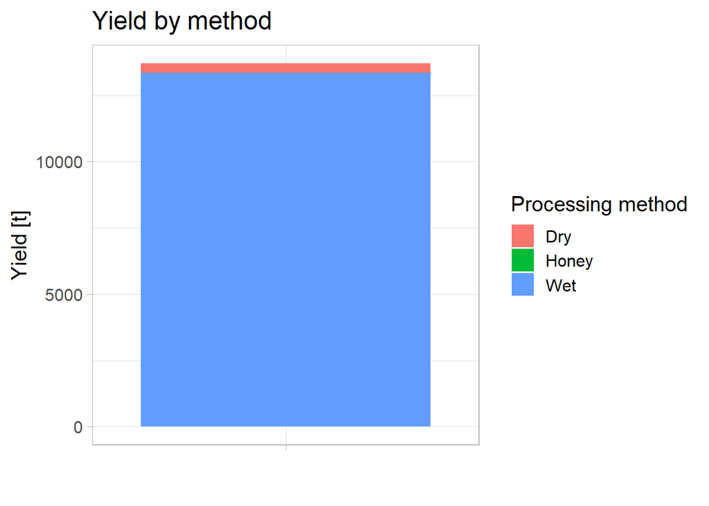

```r
clean_coffee %>%
  select(processing_method, number_of_bags, bag_weight)  %>%
  group_by(processing_method) %>%
  mutate(total_kg = number_of_bags*bag_weight/1000) %>%
  summarise(yield_t = sum(total_kg)) %>% #Ilość kawy otrzymanej za pomocą
  #obróbki Honey wynosi około 5t.
  #Dlatego nie ma sensu jej pokazywać na wykrsie
  filter(processing_method != "Pulped natural/Honey") %>%
  ggplot() +
  geom_bar(mapping = aes(x = "", y = yield_t, fill = processing_method),stat = "identity" ) +
  theme_light(base_size = 15, base_rect_size = 0.5) +
  ylab("Yield [t]") +
  xlab("") +
  ggtitle("Yield by method") +
  scale_fill_discrete(name = "Processing method")
```

Jak widać największe zbiory zostały osiągnięte za pomocą obróbek mokrych.

## **Pytanie 4:** *Czy istnieje zależność między wysokością upraw a osiąganymi nutami smakowymi?*

W teorii powinna istnieć zależność między wysokością upraw a doznaniami smakowymi.  
W górach, kawowce dłużej dojrzewają, co przekłada się na zawartość ziarna.  
Aby to sprawdzić należy najpierw sprawdzić rozkład zmiennej `altitude`.

```r
describe(clean_coffee$altitude)
```

```
##    vars   n mean     sd median trimmed    mad min  max range skew kurtosis
## X1    1 189 1318 746.31   1340  1282.4 385.48 139 5400  5261 2.42    11.56
##       se
## X1 54.29
```

Jak widać po współczynniku skośności oraz kurtozie nie mamy doczynienia z rozkładem normalnym.

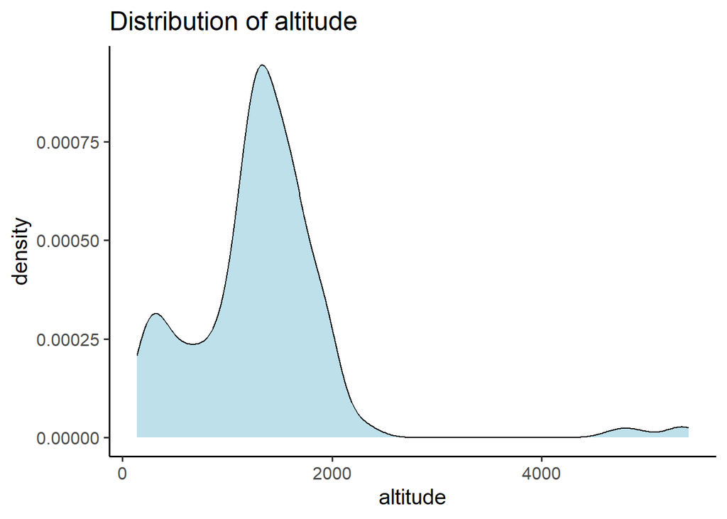

```r
clean_coffee %>%
  ggplot()+
  geom_density(mapping = aes(x = altitude), fill = "lightblue", alpha = 0.8) +
  theme_classic(base_size = 15,
                base_rect_size = 0.5)+
  ggtitle("Distribution of altitude")
```

Zatem przy liczeniu korelacji posłużymy się współczynnikiem korelacji spearmana.

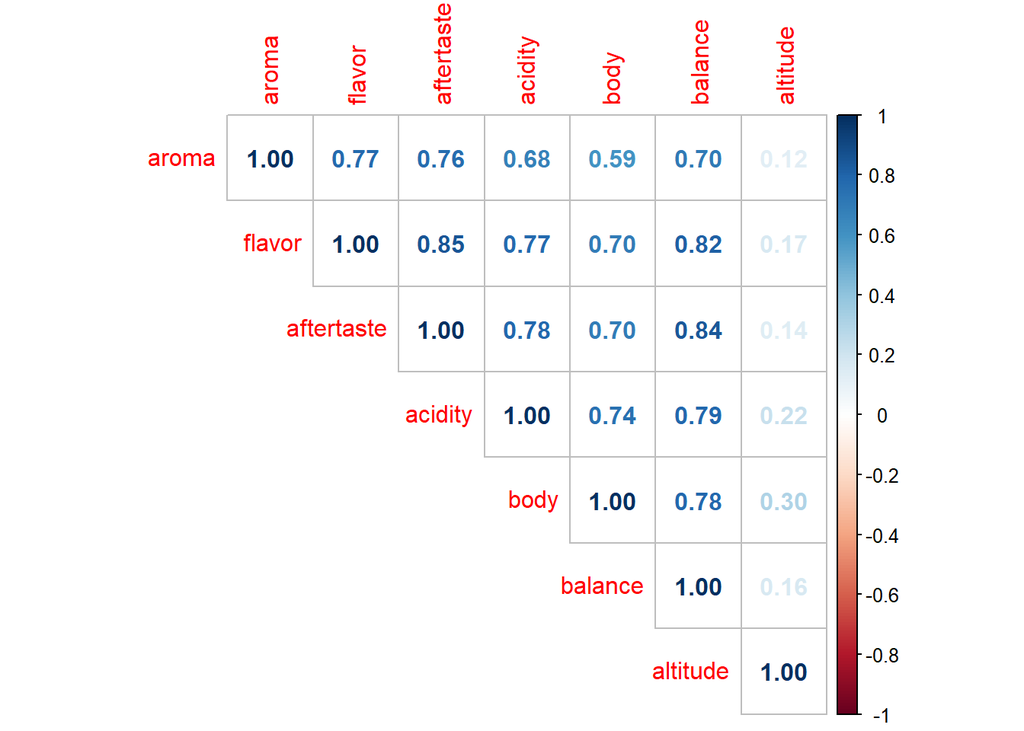

```r
cor = cor(clean_coffee[,c("aroma","flavor","aftertaste","acidity","body","balance","altitude")],
          method = "spearman")

corrplot(cor, method = "number", type = "upper")
```

Jak widać nie ma dużej zależności między nutami smakowymi, a wysokością.  
Co prawda istnieje słaba zależności między body, a wysokością.

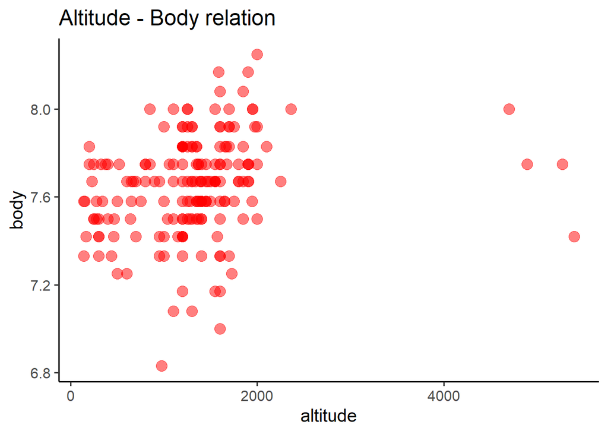

```r
clean_coffee %>%
  ggplot() +
  geom_point(mapping = aes(x = altitude, y = body),color = "red", size = 4, alpha = 0.5) +
  theme_classic(base_size = 15,
                base_rect_size = 0.5)+
  ggtitle("Altitude - Body relation")
```

Jednak o wiele ciekawsza wydaje się być zależność między poszczególnymi aromatami.  
Najsilniejszą zależność z innymi atrybutami zdaje się mieć balans, smak, posmak oraz kwaskowość.

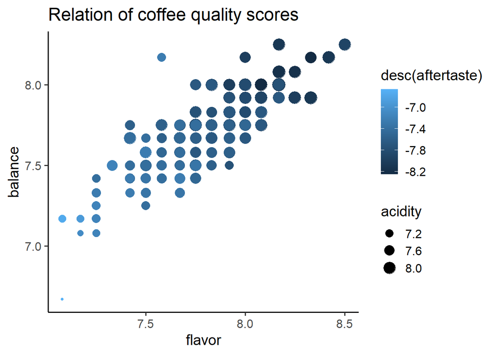

```r
clean_coffee %>%
  ggplot() +
  geom_point(mapping = aes(x = flavor, y = balance, col = desc(aftertaste), size = acidity))+
  theme_classic(base_size = 15,
                base_rect_size = 0.5)+
  ggtitle("Relation of coffee quality scores")
```

Jak widać istnieje zależność pomiędzy zależność pomiędzy profilami smakowymi kawy.

## **Pytanie 5:** *Jakie były najpopularniejsze odmiany kawy?*

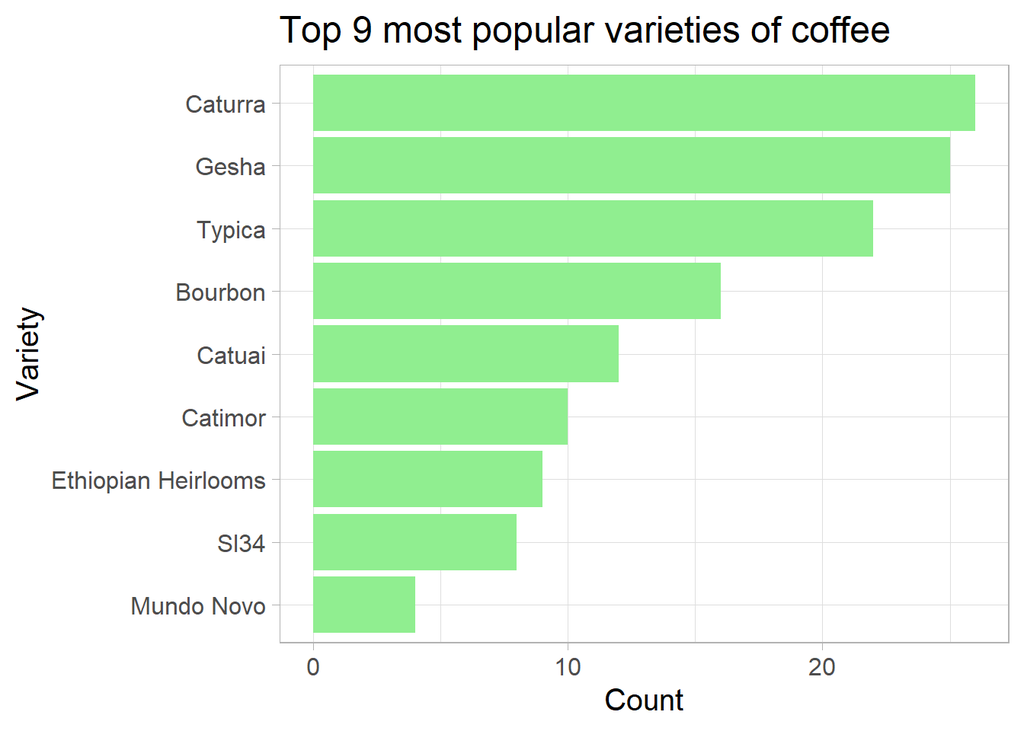

```r
clean_coffee %>%
  group_by(variety) %>%
  count(variety) %>%
  filter(n >3, variety != "Unknown") %>% #Usuwamy odmiany, które nie zostały sprecyzowane przez dostawcę.
  ggplot() +
  geom_col(mapping = aes(x= n, y = reorder(variety, n)), fill = "lightgreen") +
  theme_light(base_size = 15, base_rect_size = 0.5) +
  xlab("Count") +
  ylab("Variety") +
  ggtitle("Top 9 most popular varieties of coffee")
```

Najwidoczniej o miejsce najpopularniejszej kawy walcza Caturra oraz Gesha.  
Gesha zaczęła zyskiwać na popularności dopiero w ostatnich latach stąd pojawia się następne pytanie:

## **Pytanie 6:** *Jak popularność odmian kawy wyglądała w poszczególnych okresach?*

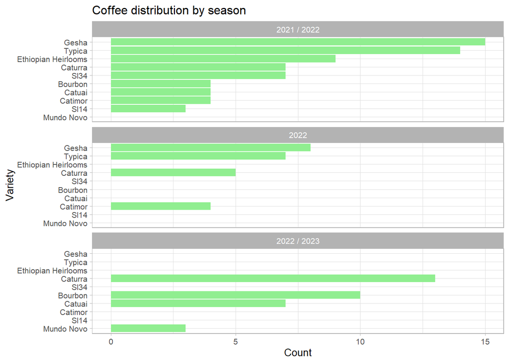

```r
clean_coffee %>%
  group_by(harvest_year, variety) %>%
  count(variety) %>%
  filter(n>2, variety != "Unknown") %>%
  ggplot() +
  facet_wrap(~harvest_year, ncol = 1) +
  geom_col(mapping = aes(x= n, y = reorder(variety, n)), fill = "lightgreen") +
  theme_light(base_size = 10, base_rect_size = 0.5) +
  xlab("Count") +
  ylab("Variety") +
  ggtitle("Coffee distribution by season")
```

Wygląda na to, że na przestrzeni sezonów ilość zgłoszeń Geshy malała.

## **Pytanie 7:** *Z jakiej spółki pochodzi najwięcej kawy?*

```r
clean_coffee %>%
  mutate(yield_t = number_of_bags*bag_weight/1000)%>%
  group_by(company) %>%
  summarise(total = sum(yield_t)) %>%
  top_n(5, total)
```

```
## # A tibble: 5 × 2
##   company                  total
##   <chr>                    <dbl>
## 1 Ipanema Coffees          192
## 2 Itochu Corporation        56.9
## 3 Mr.Brown Cafe             76.6
## 4 Peter Schoenfeld, S.A.    57.6
## 5 yhaenu plc             12288
```

Wygląda na to, że *yhaenu plc M* dostarcza o wiele więcej kawy niż pozostałe spółki.  
Ilośc jest o tyle dziwna, że przewyższa wszystkie spółki razem wzięte.

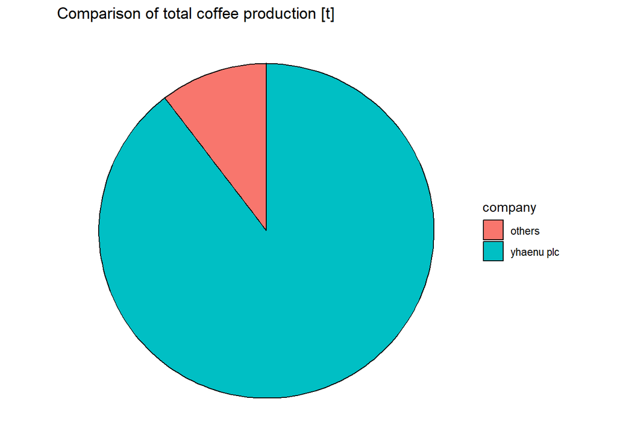

```r
clean_coffee %>%
  mutate(yield_t = number_of_bags*bag_weight/1000) %>%
  mutate(company = case_when(company != "yhaenu plc" ~ "others",
                             company == "yhaenu plc" ~ "yhaenu plc")) %>%
  group_by(company) %>%
  summarise(total = sum(yield_t)) %>%
  ggplot() +
  geom_bar(mapping = aes(x="", y=total, fill=company), stat="identity", width=1, color = "black") +
  coord_polar("y", start = 0) +
  ggtitle("Comparison of total coffee production [t]") +
  theme_void()
```

Zatem może lepiej spróbować bez tej spółki:

```r
clean_coffee %>%
  mutate(yield_t = number_of_bags*bag_weight/1000)%>%
  filter(company != "yhaenu plc") %>%
  group_by(company) %>%
  summarise(total = sum(yield_t)) %>%
  top_n(5, total)
```

```
## # A tibble: 5 × 2
##   company                      total
##   <chr>                        <dbl>
## 1 Consejo Salvadoreño del Café  55.0
## 2 Ipanema Coffees              192
## 3 Itochu Corporation            56.9
## 4 Mr.Brown Cafe                 76.6
## 5 Peter Schoenfeld, S.A.        57.6
```

Skłaniam się bardziej w kierunku tych wyników.

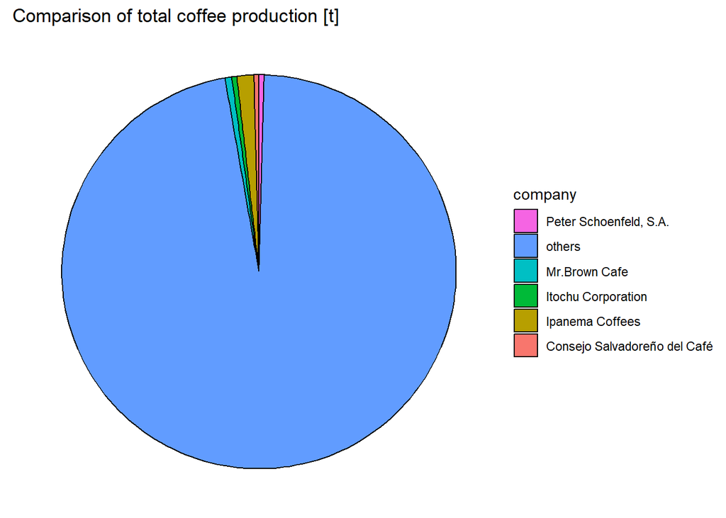

```r
top5 <- c("Consejo Salvadoreño del Café", "Ipanema Coffees",
          "Itochu Corporation", "Mr.Brown Cafe", "Peter Schoenfeld, S.A.")

clean_coffee %>%
  mutate(yield_t = number_of_bags*bag_weight/1000) %>%
  mutate(company = case_when(!company %in% top5 ~ "others",
                             company %in% top5 ~ company)) %>%
  group_by(company) %>%
  summarise(total = sum(yield_t)) %>%
  ggplot() +
  geom_bar(mapping = aes(x="", y=total, fill=company), stat="identity", width=1, color = "black") +
  coord_polar("y", start = 0) +
  ggtitle("Comparison of total coffee production [t]") +
  guides(fill = guide_legend(reverse=TRUE)) +
  theme_void()
```

Widać zatem, że top 5 największych spółek stanowi ledwie frakcję całej produkcji.

## **Pytanie 8:** *Czy istnieje zależność między kolorem kawy po obróbce, a osiąganymi wynikami?*

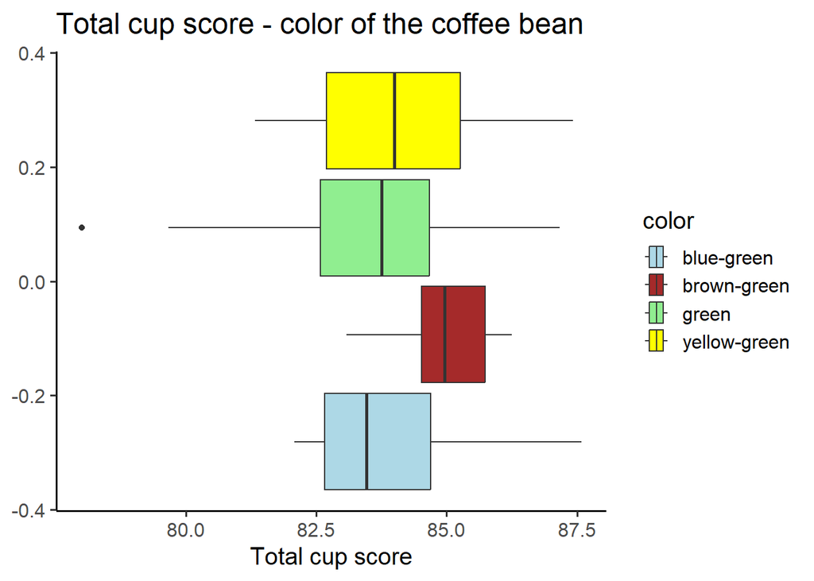

```r
clean_coffee %>%
  group_by(color) %>%
  ggplot() +
  geom_boxplot(mapping = aes(x = total_cup_points, fill = color)) +
  theme_classic(base_size = 15,
                base_rect_size = 0.5) +
  xlab("Total cup score") +
  ggtitle("Total cup score - color of the coffee bean") +
  scale_fill_manual(values=c("lightblue", "brown", "lightgreen", "yellow"))
```

Widać zatem, że istenieje pewna skłonność wśród recenzentów do  
wyższego oceniania kaw, które zostały wypalone z ziaren o brązowo-zielonym kolorze.

## **Pytanie 9:** *Czy istnieje zależność pomiędzy odmianą kawy, a jej kolorem?*

W tym przypadku mamy do czynienia z danymi jakościowymi zatem posłużę się  
funkcją do obliczenia *V-cramera* z pakietu `rcompanion`.

```r
cramerV(clean_coffee$variety,clean_coffee$color)
```

```
## Cramer V
##   0.5502
```

Jak na zmienne jakościowe jest do wynik całkiem wysoki, spróbujmy to przedstawić na wykresie.  
Wykorzystam do tego 10 najliczniejszych odmian.

```r
variety_counts <- table(clean_coffee$variety)
top_10_varieties <- names(sort(variety_counts, decreasing = TRUE)[1:11])
top_varieties_data <- subset(clean_coffee, variety %in% top_10_varieties)
```

Otrzymuje w ten sposób ramkę danych z 10 najliczniejszymi odmianami.  
Odmiany o wartości `Unknown` będą do usunięcia.

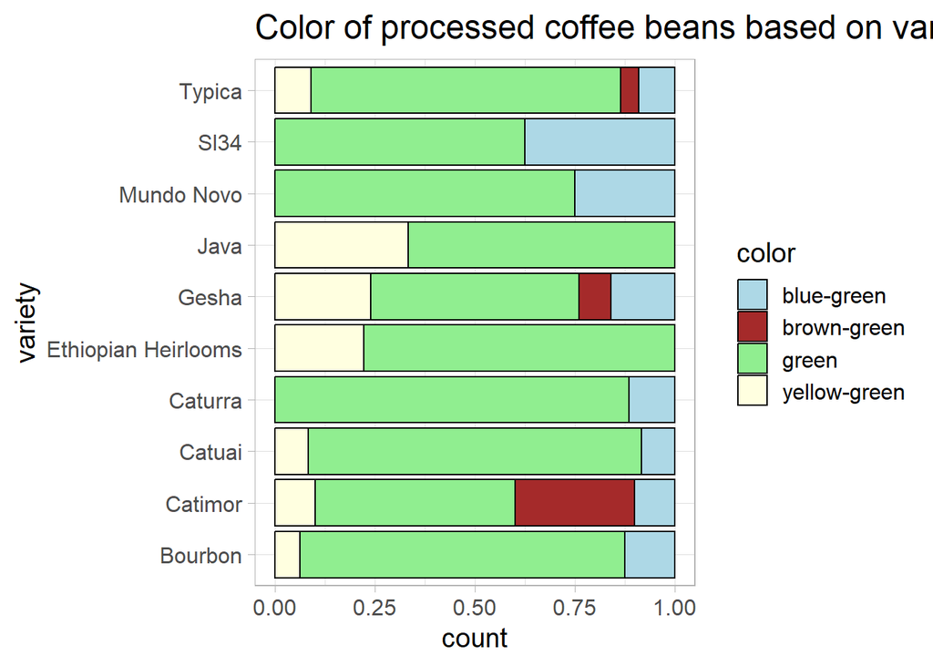

```r
top_varieties_data %>%
  filter(variety != "Unknown") %>%
  group_by(variety, color) %>%
  ggplot() +
  geom_bar(mapping = aes(y = variety, fill = color), color = "black", position = "fill") +
  theme_light(base_size = 15,
              base_rect_size = 0.5) +
  ggtitle("Color of processed coffee beans based on variety") +
  scale_fill_manual(values=c("lightblue", "brown", "lightgreen", "lightyellow"))
```

Wygląda na to, że rzeczywiście w zależności od odmiany zmienia  
się ilość występujących kolorów kawy.  
Jednak nie przekonuje mnie to w 100%.  
Stąd pojawia się ostatnie pyanie:

## **Pytanie 10:** *Czy sposób przetwarzania kawy wpływa na jej kolor?*

Zacznijmy od policzenia korelacji.

```r
cramerV(clean_coffee$processing_method,clean_coffee$color)
```

```
## Cramer V
##   0.3457
```

Jest to całkiem niski wynik. Zobaczmy co przedstawi wykres.

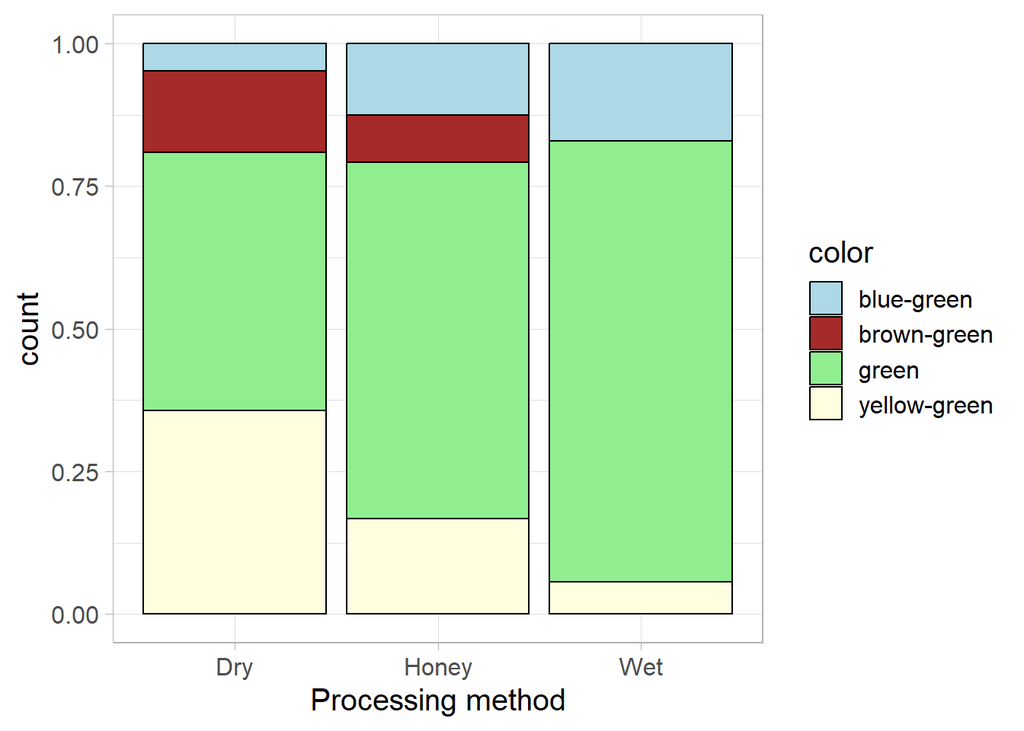

```r
clean_coffee %>%
 group_by(processing_method, color) %>%
  ggplot() +
  geom_bar(mapping = aes(x = processing_method, fill = color), color = "black", position = "fill") +
  xlab("Processing method")+
  theme_light(base_size = 15,
              base_rect_size = 0.5)+
  scale_fill_manual(values=c("lightblue", "brown", "lightgreen", "lightyellow"))
```

Wygląda na to, że rzeczywiście w zależności od dobranej metody  
różni się udział uzyskanych kolorów kawy.  
Pytaniem które mi się nasunęło po zobaczeniu tego wykresu jest to:  
*jak zmienia się wynik tego wykresu w zależności od odmiany kawy?*  
Przeczuwam, że różne metody będą wykorzystywane do różnych odmian.  
Co jeszcze bardziej wpłynie na otrzymywany kolor ziaren.

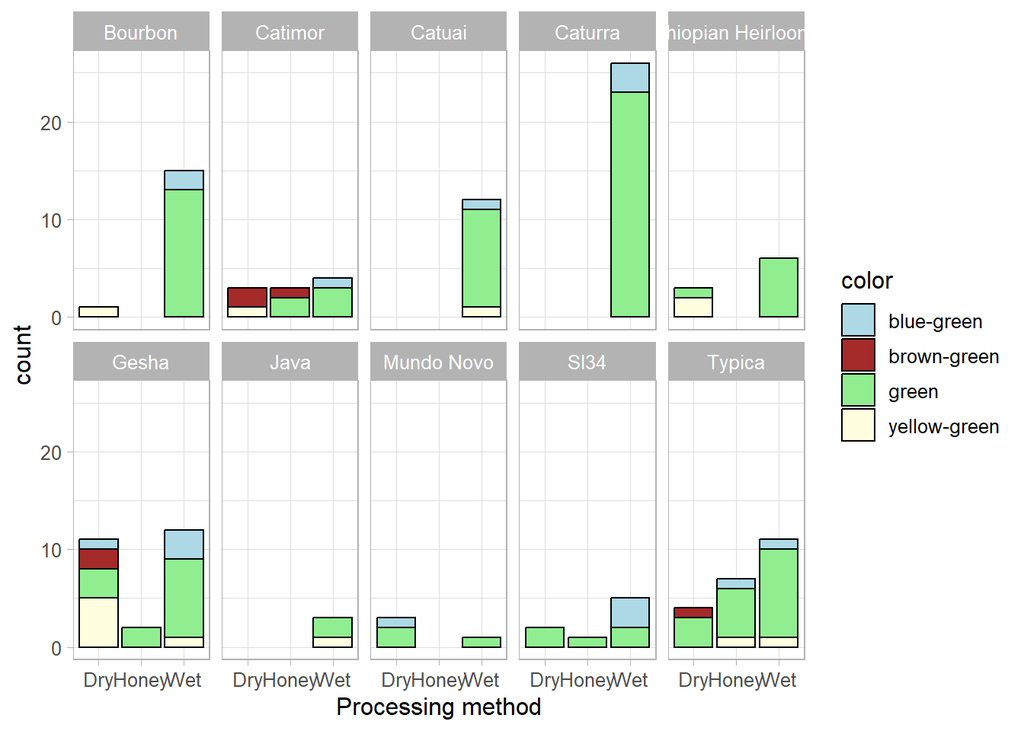

```r
top_varieties_data %>%
  filter(variety != "Unknown") %>%
  group_by(processing_method, color) %>%
  ggplot() +
  facet_wrap(~variety,nrow = 2) +
  geom_bar(mapping = aes(x = processing_method, fill = color), color = "black", position = "stack") +
  xlab("Processing method")+
  theme_light(base_size = 12,
              base_rect_size = 0.5)+
  scale_fill_manual(values=c("lightblue", "brown", "lightgreen", "lightyellow"))
```

Wygląda na to, że niektóre odmiany w zależności od wybranego procesu, rzeczywiście są podatniejsze  
na uzyskanie innych kolorów np. odmiana Gesha, obrabiana metodą Dry.  
Mimo wszystko nie ma wystarczająco dużo obserwacji w danych katerogariach, aby nie odrzucić danej hipotezy.

**Dziękuję za uwagę**